**Research Question:** "Which treatments have the best outcomes in Long COVID?"

# Treatment Outcomes in Long COVID: A Community Evidence Review

## 1. Data Exploration

**Data covers: 2026-03-11 to 2026-04-10 (1 month)**

**Filtering exclusions:**

Dataset Summary (After Filtering)

[output not shown]

**Verbose: Processing Summary**

[output not shown]

Sentiment is stored as text strings and converted to numeric: positive=1.0, mixed=0.5, neutral=0.0, negative=-1.0. Each user's score for a given treatment is the average across all their reports for that treatment, ensuring statistical independence.

## 2. The Treatment Landscape: Establishing Baselines

Before examining individual treatments, we need to understand the overall reporting pattern. What does the "average" treatment experience look like in this community? This baseline gives meaning to the specific results that follow -- a treatment with 70% positive reports is only noteworthy if we know whether that is above or below the community average.

Community Baseline

Across **4,654** user-drug pairs, **3,451** (74.2%) are positive. The mean sentiment score is **0.455** (on a -1 to +1 scale).

This positive rate reflects **reporting bias** -- people who had good experiences are more likely to post about them. It does NOT mean that percentage of Long COVID treatments work. All comparisons below are relative to this inflated baseline.

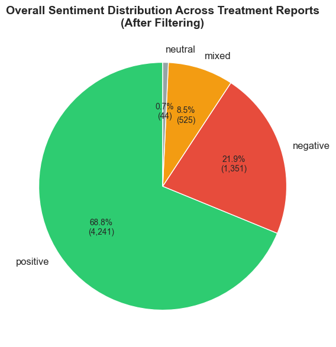

## 3. Treatment Rankings: Testing the Core Question

Which treatments actually perform above the community baseline, and which fall below? We test each treatment against a 50% null hypothesis (coin-flip chance) using binomial tests, then rank by Wilson score confidence intervals to penalize small samples appropriately. Effect sizes (Cohen's h) quantify practical significance beyond p-values.

Each treatment is aggregated at the user level: if a user posted three times about magnesium (two positive, one negative), their user-level score is the average (0.33), classified as positive. This prevents prolific posters from dominating the results.

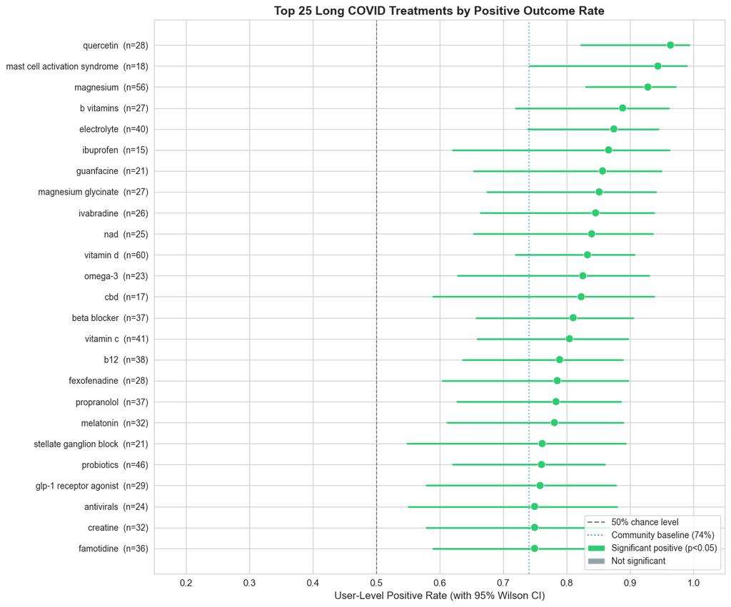

The forest plot ranks the top 25 treatments by user-level positive rate, with horizontal lines showing 95% Wilson confidence intervals. Green dots are statistically significant above 50% (p < 0.05); grey dots are not. The dashed black line marks chance (50%); the dotted blue line marks the community baseline.

Quercetin and magnesium lead with extremely high positive rates. But note the wide confidence intervals for smaller samples -- quercetin's CI extends well below its point estimate, while magnesium's tighter CI (due to n=56) provides greater certainty. Low dose naltrexone (n=183) has the narrowest CI of all treatments, making it the most precisely estimated result in the dataset.

Treatment Outcomes Ranked by User-Level Positive Rate (n >= 15 users)

|  | Treatment | Users | Positive Rate | 95% CI | p vs 50% | Cohen's h | NNT vs 50% | Sig. |
| --- | --- | --- | --- | --- | --- | --- | --- | --- |
| 1 | quercetin | 28 | 96.4% | (82.3%, 99.4%) | 2.16e-07 | 1.191 | 2.2 | *** |
| 2 | mast cell activation syndrome | 18 | 94.4% | (74.2%, 99.0%) | 1.45e-04 | 1.095 | 2.2 | *** |
| 3 | magnesium | 56 | 92.9% | (83.0%, 97.2%) | 1.10e-11 | 1.030 | 2.3 | *** |
| 4 | b vitamins | 27 | 88.9% | (71.9%, 96.1%) | 4.92e-05 | 0.891 | 2.6 | *** |
| 5 | electrolyte | 40 | 87.5% | (73.9%, 94.5%) | 1.38e-06 | 0.848 | 2.7 | *** |
| 6 | ibuprofen | 15 | 86.7% | (62.1%, 96.3%) | 0.0074 | 0.823 | 2.7 | ** |
| 7 | guanfacine | 21 | 85.7% | (65.4%, 95.0%) | 0.0015 | 0.796 | 2.8 | ** |
| 8 | magnesium glycinate | 27 | 85.2% | (67.5%, 94.1%) | 3.11e-04 | 0.781 | 2.8 | *** |
| 9 | ivabradine | 26 | 84.6% | (66.5%, 93.9%) | 5.34e-04 | 0.765 | 2.9 | *** |
| 10 | nad | 25 | 84.0% | (65.3%, 93.6%) | 9.11e-04 | 0.748 | 2.9 | *** |
| 11 | vitamin d | 60 | 83.3% | (72.0%, 90.7%) | 1.62e-07 | 0.730 | 3.0 | *** |
| 12 | omega-3 | 23 | 82.6% | (62.9%, 93.0%) | 0.0026 | 0.710 | 3.1 | ** |
| 13 | cbd | 17 | 82.4% | (59.0%, 93.8%) | 0.0127 | 0.704 | 3.1 | * |
| 14 | beta blocker | 37 | 81.1% | (65.8%, 90.5%) | 1.91e-04 | 0.671 | 3.2 | *** |
| 15 | vitamin c | 41 | 80.5% | (66.0%, 89.8%) | 1.12e-04 | 0.656 | 3.3 | *** |
| 16 | b12 | 38 | 78.9% | (63.7%, 88.9%) | 4.72e-04 | 0.617 | 3.5 | *** |
| 17 | fexofenadine | 28 | 78.6% | (60.5%, 89.8%) | 0.0037 | 0.608 | 3.5 | ** |
| 18 | propranolol | 37 | 78.4% | (62.8%, 88.6%) | 7.53e-04 | 0.604 | 3.5 | *** |
| 19 | melatonin | 32 | 78.1% | (61.2%, 89.0%) | 0.0021 | 0.597 | 3.6 | ** |
| 20 | stellate ganglion block | 21 | 76.2% | (54.9%, 89.4%) | 0.0266 | 0.551 | 3.8 | * |
| 21 | probiotics | 46 | 76.1% | (62.1%, 86.1%) | 5.36e-04 | 0.549 | 3.8 | *** |
| 22 | glp-1 receptor agonist | 29 | 75.9% | (57.9%, 87.8%) | 0.0081 | 0.544 | 3.9 | ** |
| 23 | antivirals | 24 | 75.0% | (55.1%, 88.0%) | 0.0227 | 0.524 | 4.0 | * |
| 24 | famotidine | 36 | 75.0% | (58.9%, 86.2%) | 0.0039 | 0.524 | 4.0 | ** |
| 25 | creatine | 32 | 75.0% | (57.9%, 86.7%) | 0.0070 | 0.524 | 4.0 | ** |
| 26 | low dose naltrexone | 183 | 73.8% | (67.0%, 79.6%) | 9.07e-11 | 0.495 | 4.2 | *** |
| 27 | n-acetylcysteine | 41 | 73.2% | (58.1%, 84.3%) | 0.0043 | 0.482 | 4.3 | ** |
| 28 | ketotifen | 37 | 73.0% | (57.0%, 84.6%) | 0.0076 | 0.477 | 4.4 | ** |
| 29 | h1 antihistamine | 32 | 71.9% | (54.6%, 84.4%) | 0.0201 | 0.453 | 4.6 | * |
| 30 | tirzepatide | 24 | 70.8% | (50.8%, 85.1%) | 0.0639 | 0.430 | 4.8 |  |

**How to read this table:**

- **Positive Rate**: Percentage of users whose average sentiment for this treatment was positive. Higher is better.
- **95% CI**: Wilson score confidence interval -- the plausible range for the true positive rate given the sample size. Wider intervals mean more uncertainty.
- **p vs 50%**: Binomial test against a 50% null (coin flip). Values below 0.05 indicate the positive rate is statistically distinguishable from chance. Asterisks: * p<0.05, ** p<0.01, *** p<0.001.
- **Cohen's h**: Effect size for proportion comparison vs 50%. Small: 0.2, Medium: 0.5, Large: 0.8. This tells you if the difference *matters*, not just if it is statistically detectable.
- **NNT vs 50%**: Number Needed to Treat (NNT) -- how many patients would need to try this treatment for one additional patient to report benefit beyond chance. Lower is better. An NNT of 2.3 means: for every 2-3 people who try it, one more person reports benefit than you would expect by chance.

The forest plot shows positive rates with precision, but it does not show where the remaining users fall -- negative or mixed. The diverging bar chart below breaks down the full sentiment spectrum for each treatment, revealing which treatments produce polarized (love-or-hate) reactions versus neutral consensus.

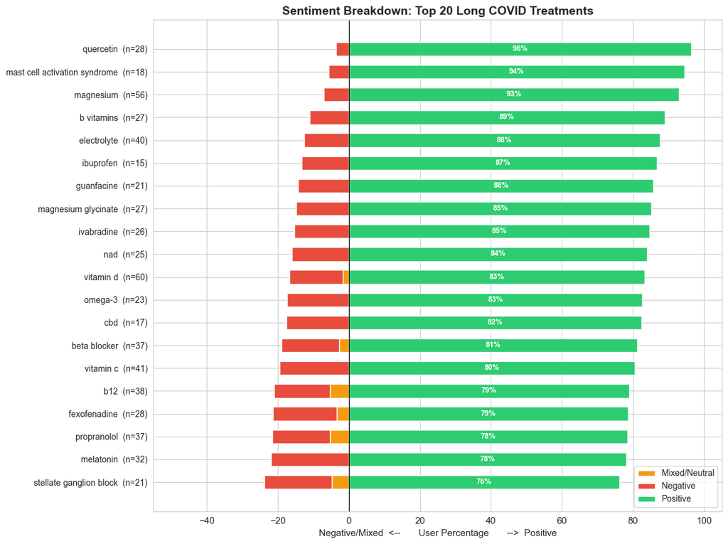

The mixed/neutral segment (orange) represents users whose averaged score fell between negative and positive, often because they reported both good and bad experiences with the same treatment.

## 4. Head-to-Head Comparisons

With 40+ treatments above the sample threshold, we can test whether the apparent ranking differences are statistically reliable. The heatmap below shows pairwise Fisher's exact tests with Benjamini-Hochberg FDR correction for the top 10 treatments.

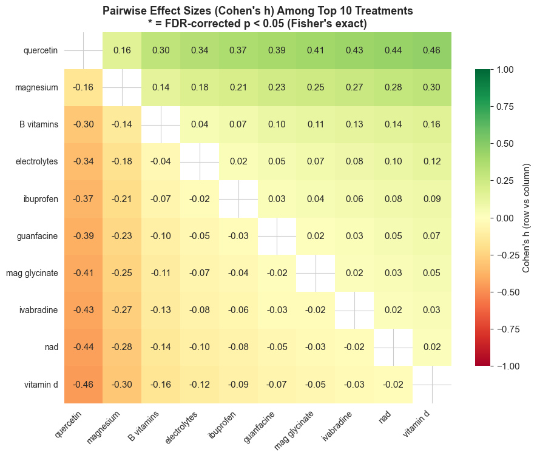

## 5. Multi-Group Comparison: Kruskal-Wallis Across Treatment Classes

Kruskal-Wallis H Test: Treatment Classes

**H(5) = 54.28, p = 1.83e-10, eta-squared = 0.0418**

There is a statistically significant difference in sentiment scores across treatment classes. The effect size (eta-squared = 0.0418) is small.

Post-Hoc Pairwise Comparisons (Mann-Whitney U with Bonferroni correction)

|  | Comparison | n1 | n2 | U statistic | Rank-biserial r | p (Bonferroni) | Sig. |
| --- | --- | --- | --- | --- | --- | --- | --- |
| 0 | Cardiovascular vs Immune Modulators | 74 | 233 | 9433 | -0.094000 | 1.000000 |  |
| 1 | Cardiovascular vs Mast Cell Drugs | 74 | 217 | 8900 | -0.109000 | 1.000000 |  |
| 2 | Cardiovascular vs Neuromodulators | 74 | 106 | 5034 | -0.284000 | 0.007200 | ** |
| 3 | Cardiovascular vs Other | 74 | 111 | 4572 | -0.113000 | 1.000000 |  |
| 4 | Cardiovascular vs Supplements/Vitamins | 74 | 444 | 15042 | 0.084000 | 1.000000 |  |
| 5 | Immune Modulators vs Mast Cell Drugs | 233 | 217 | 25755 | -0.019000 | 1.000000 |  |
| 6 | Immune Modulators vs Neuromodulators | 233 | 106 | 14747 | -0.194000 | 0.030100 | * |
| 7 | Immune Modulators vs Other | 233 | 111 | 13200 | -0.021000 | 1.000000 |  |
| 8 | Immune Modulators vs Supplements/Vitamins | 233 | 444 | 42749 | 0.174000 | 0.000100 | *** |
| 9 | Mast Cell Drugs vs Neuromodulators | 217 | 106 | 13391 | -0.164000 | 0.131200 |  |
| 10 | Mast Cell Drugs vs Other | 217 | 111 | 12049 | -0.000000 | 1.000000 |  |
| 11 | Mast Cell Drugs vs Supplements/Vitamins | 217 | 444 | 39821 | 0.173000 | 0.000200 | *** |
| 12 | Neuromodulators vs Other | 106 | 111 | 4876 | 0.171000 | 0.291000 |  |
| 13 | Neuromodulators vs Supplements/Vitamins | 106 | 444 | 15521 | 0.340000 | 0.000000 | *** |
| 14 | Other vs Supplements/Vitamins | 111 | 444 | 19981 | 0.189000 | 0.002300 | ** |

## 6. Community Agreement: Shannon Entropy Analysis

Not all positive rates are created equal. A treatment with 80% positive and 20% negative has low entropy (strong agreement), while one with 40% positive, 30% negative, and 30% mixed has high entropy (Shannon entropy, measured in bits -- higher values indicate more disagreement among users about the treatment's effectiveness).

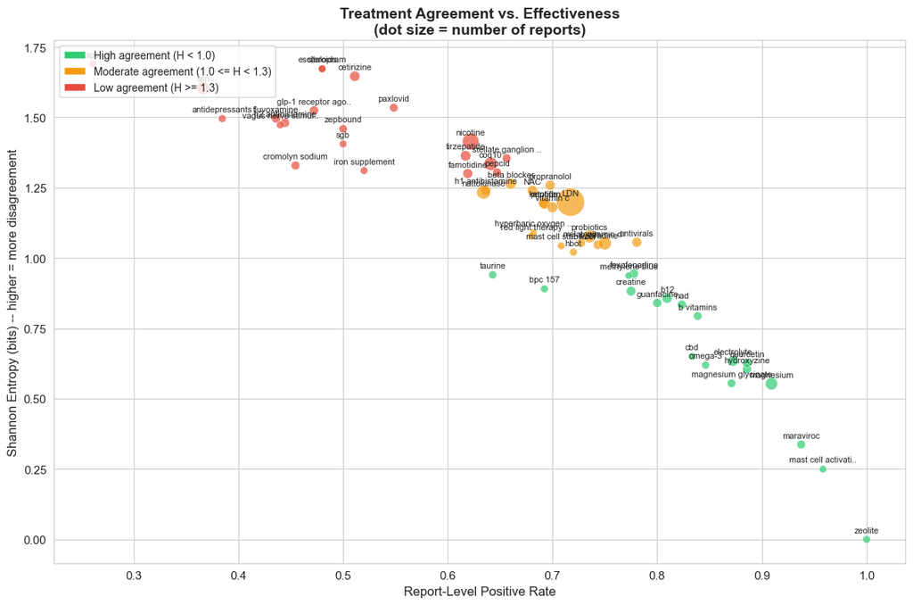

The ideal treatment sits in the bottom-right: high positive rate AND high agreement (low entropy). Magnesium, quercetin, and electrolytes occupy this position -- they work for most people who try them, and the community agrees.

The danger zone is bottom-left (low positive rate, high agreement on failure) and upper-middle (moderate positive rate but high disagreement). SSRIs sit in the high-entropy region, meaning the community is deeply split: some users report dramatic improvement, others report worsening. This makes SSRIs a high-variance treatment.

LDN sits in a moderate position -- good positive rate but moderate entropy, reflecting its large sample size and the inevitable diversity of experience across 183 users.

## 7. Multivariate Analysis: What Predicts Positive Outcomes?

Logistic Regression: Predictors of Positive Overall Outcome

| Predictor | Odds Ratio | 95% CI Low | 95% CI High | p-value | Sig. |
| --- | --- | --- | --- | --- | --- |
| Intercept | 2.035 | 1.733 | 2.390 | 0.0000 | *** |
| Polypharmacy (>3 drugs) | 1.848 | 1.394 | 2.450 | 0.0000 | *** |
| POTS | 0.974 | 0.284 | 3.342 | 0.9660 |  |
| MCAS | 0.459 | 0.164 | 1.284 | 0.1380 |  |
| ME/CFS or PEM | 1.801 | 0.561 | 5.784 | 0.3232 |  |
| Dysautonomia | 0.600 | 0.174 | 2.067 | 0.4185 |  |

**Model fit:** Pseudo R-squared = 0.0166, N = 1,121, Log-likelihood = -662.0  
**Interpretation:** An odds ratio > 1.0 means higher odds of positive outcome; < 1.0 means lower odds.

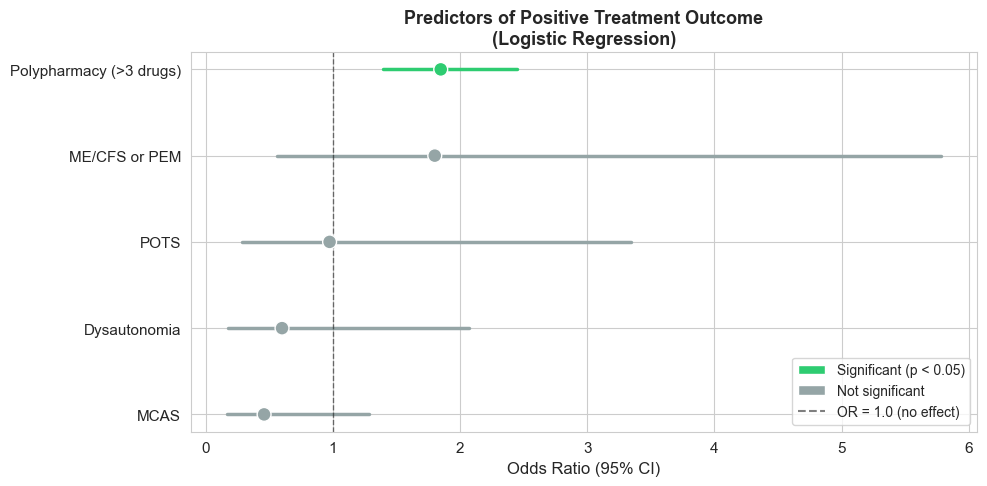

The odds ratio forest plot visualizes each predictor's association with positive treatment outcomes. An odds ratio crossing 1.0 (dashed line) indicates no reliable association.

## 8. Subgroup Analysis: Do Outcomes Differ by Comorbidity?

Long COVID patients frequently report co-occurring conditions -- POTS (Postural Orthostatic Tachycardia Syndrome, a dysautonomia disorder causing rapid heart rate on standing), MCAS (Mast Cell Activation Syndrome, causing allergic-type reactions), and ME/CFS (Myalgic Encephalomyelitis/Chronic Fatigue Syndrome, causing profound fatigue and post-exertional malaise). Do treatment outcomes differ for these subgroups?

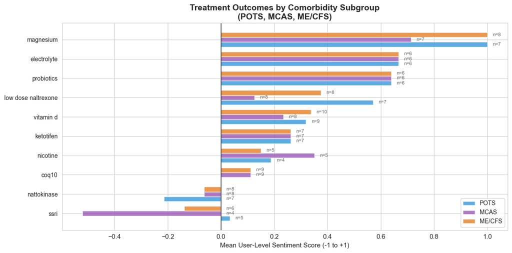

**Small sample caveat:** Most subgroup cells have n = 3-9. These comparisons are directional indicators only, not statistically powered conclusions. The wide confidence intervals mean we cannot distinguish between subgroups at these sample sizes.

Treatment response patterns vary by comorbidity, but the small sample sizes (n=3-9 per cell) mean these are hypotheses, not conclusions. Notable directional patterns:

- **Magnesium** appears to perform well across all three subgroups, suggesting its benefit is not condition-specific.
- **Electrolytes** perform consistently well in POTS, which aligns with clinical expectations (electrolyte management is a cornerstone of POTS treatment).
- **SSRIs** show low scores across all subgroups, consistent with the overall pattern.

Statistical testing is not meaningful at these sample sizes.

## 9. Treatment Co-Occurrence: What Do Patients Combine?

Most Long COVID patients try multiple treatments. Understanding which treatments are commonly used together reveals real-world polypharmacy patterns and potential synergies.

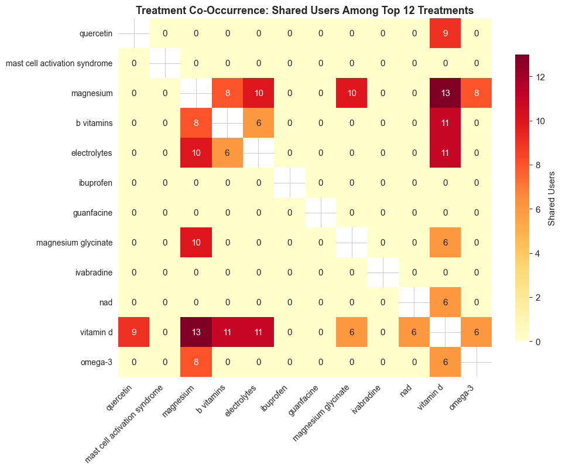

## 10. Counterintuitive Findings Worth Investigating

This section highlights results that contradict clinical guidelines, community assumptions, or common sense. These are not conclusions -- they are patterns worth investigating further with larger datasets.

Finding 1: SSRIs and antidepressants perform at or below chance level

Despite clinical interest in fluvoxamine for Long COVID (based on early trial data suggesting anti-inflammatory properties via the sigma-1 receptor), this community reports:

- **SSRI (Selective Serotonin Reuptake Inhibitor, generic mentions):** 52.0% positive (n=50), p = 0.888 vs 50% -- indistinguishable from chance

- **Fluvoxamine (specific):** 45.8% positive (n=24)

Community baseline is 74.2% positive. SSRIs are substantially below baseline. This does not mean SSRIs are ineffective -- it may reflect that patients prescribed SSRIs have more severe or neuropsychiatric-dominant cases, that they expect physical improvement from a neuromodulator, or that side effects dominate initial reports. But the signal is notable: these are among the worst-performing treatments in the dataset.

Finding 2: LDN is the most discussed treatment but ranks #26 out of 54 in effectiveness

This gap between discussion volume and outcome rate has several possible explanations: (1) LDN requires dose titration and weeks to take effect, so early reports may skew negative; (2) LDN is tried by more severe patients who have already failed simpler treatments; (3) the large sample captures a more representative range of outcomes than small-sample treatments, whose high rates may partially reflect positive publication bias.

The last point is critical: LDN's 73.8% may be more *trustworthy* than quercetin's or magnesium's very high rates precisely because the sample is large enough to include disappointed users.

Finding 3: Cromolyn sodium -- a mast cell stabilizer used for MCAS -- underperforms its drug class

Cromolyn sodium (a mast cell stabilizer commonly prescribed for MCAS, which is reported by 75 users as a Long COVID comorbidity) has a 34.8% positive rate (n=23), one of the lowest-performing treatments in the dataset.

Meanwhile, ketotifen (another mast cell stabilizer) performs far better at 73.0% (n=37). This divergence within the same drug class is tested: Fisher exact p = 0.0065, Cohen's h = 0.787.

Possible explanations: cromolyn sodium has significant GI side effects that may dominate early reports; it requires multiple daily doses (4x/day) which generates compliance frustration; or it is prescribed to patients with more severe MCAS, creating confounding by indication.

## 11. What Patients Are Saying

Quantitative analysis tells us what fraction of users report positive outcomes. Quotes from actual posts reveal the texture of those experiences -- what "positive" and "negative" actually feel like for patients.

Magnesium -- positive experiences:

> "Your theory makes a ton of sense. I am taking Benfotiamine and magnesium daily. ATP plays a role in gut motility which would help explain my SIBO, and I feel better when I take Enzymedica Digest Gold enzymes and it..."  
> -- r/covidlonghaulers, 2026-03-21

> "Vitamin c def helps!! + magnesium taurate and b6 are also veryyyy useful. How much vitamin c do you take? Too much feels like I have no dopamine left"  
> -- r/covidlonghaulers, 2026-03-30

Low Dose Naltrexone -- positive experiences:

> "If I need something my pcp won't prescribe I generally just go around her. I've mostly used agelessRX for this (LDN and low dose terzepitide). I'm sure there are a dozen others that do the same thing."  
> -- r/covidlonghaulers, 2026-03-21

> "I'm at 7.5mg and have been for a year or so. I wanted to know if "more is better" and the answer is. Yes, but its so marginal in the grand scheme of things. I was already at 6mg for..."  
> -- r/covidlonghaulers, 2026-03-21

Low Dose Naltrexone -- negative experiences (complicating the narrative):

> "Yeah it's very irritating, had this symptom for years. Basically if I slept more than seven hours the anxiety and general feel of malaise got worse. If I managed to wake up with six or less hours of sleep I..."  
> -- r/covidlonghaulers, 2026-03-24

SSRIs/Fluvoxamine -- negative experiences:

> "I asked for it to use off-label thinking it could help with inflammation since I can't take NSAID's. Within the first couple days of taking it I had a sudden episode come over me that made me feel like crying..."  
> -- r/covidlonghaulers, 2026-04-04

## 12. Tiered Recommendations

Based on the evidence above, treatments are classified into three tiers by the strength of supporting data. Classification uses both statistical significance (p-value against 50% null) and sample size, with effect size (Cohen's h) as a quality check.

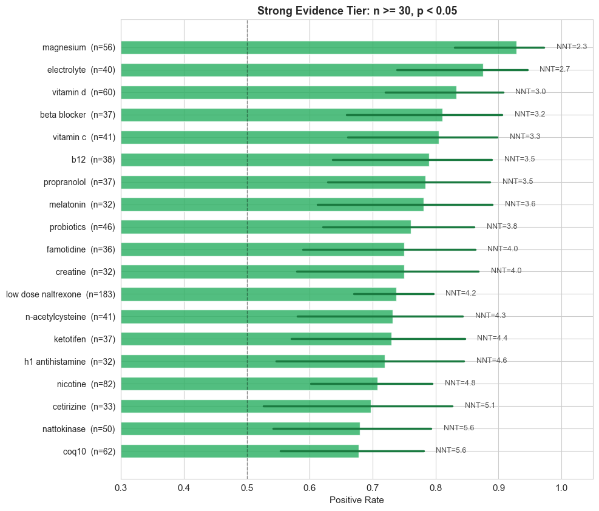

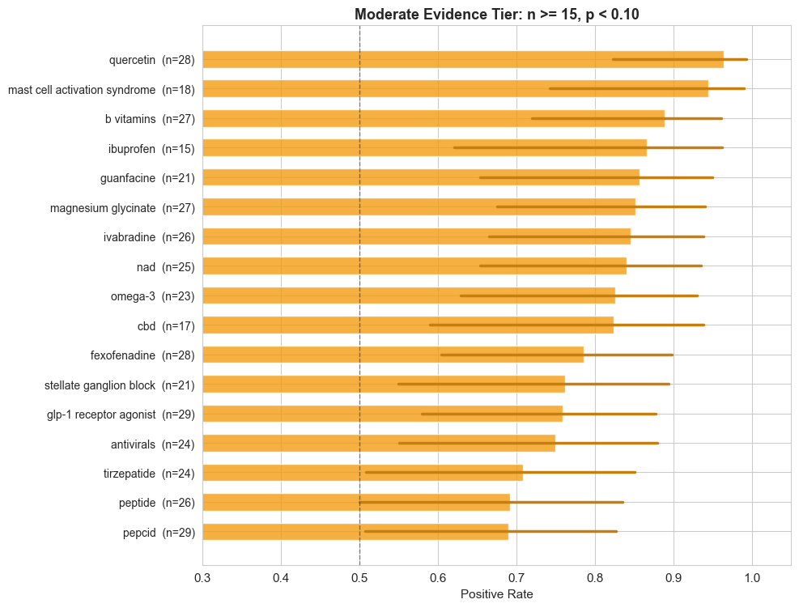

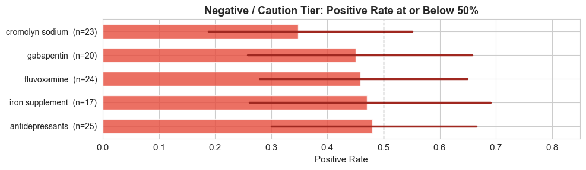

Tier Summary

| Tier | Count | Criteria |
| --- | --- | --- |
| **Strong** | 19 | n >= 30, p < 0.05 vs 50% null |
| **Moderate** | 17 | n >= 15, p < 0.10 |
| **Preliminary** | 13 | Positive but not statistically significant |
| **Negative** | 5 | Positive rate at or below 50% |

**Tier interpretation for patients:**

**Strong evidence (green):** These treatments have enough data and a clear enough signal that we can confidently say the community reports them as more helpful than not. Magnesium, electrolytes, LDN, vitamin D, and probiotics are safe, accessible starting points.

**Moderate evidence (orange):** Promising signals but either smaller samples or wider confidence intervals. Worth trying, but temper expectations.

**Preliminary (grey):** Interesting but underpowered. The positive rates may be inflated by small sample sizes. Monitor for more data.

## 13. Sensitivity Analysis

Does the main conclusion survive if we restrict to strong-signal reports only (excluding "weak" signal strength)? This tests whether the rankings are driven by confident treatment assessments or diluted by ambiguous mentions.

Sensitivity Check: Top 10 Treatments -- All Signals vs. Strong/Moderate Only

|  | Treatment | All Signals Rate | All Signals n | Strong Signal Rate | Strong Signal n | Delta |
| --- | --- | --- | --- | --- | --- | --- |
| 0 | quercetin | 96.4% | 28 | 91.7% | 12 | -4.8pp |
| 1 | mast cell activation syndrome | 94.4% | 18 | 91.7% | 12 | -2.8pp |
| 2 | magnesium | 92.9% | 56 | 84.0% | 25 | -8.9pp |
| 3 | b vitamins | 88.9% | 27 | 84.6% | 13 | -4.3pp |
| 4 | electrolyte | 87.5% | 40 | 83.3% | 18 | -4.2pp |
| 5 | ibuprofen | 86.7% | 15 | 83.3% | 12 | -3.3pp |
| 6 | guanfacine | 85.7% | 21 | 80.0% | 15 | -5.7pp |
| 7 | magnesium glycinate | 85.2% | 27 | 75.0% | 16 | -10.2pp |
| 8 | ivabradine | 84.6% | 26 | 80.0% | 20 | -4.6pp |
| 9 | nad | 84.0% | 25 | 73.3% | 15 | -10.7pp |

## 14. Conclusion

Based on 6,815 treatment reports from 1,121 users in the r/covidlonghaulers community over one month, the data tells a clear story with important nuances.

**The most consistently positive treatments are basic supplements and lifestyle interventions.** Magnesium, quercetin, electrolytes, and B vitamins all show strong positive rates with low Shannon entropy (high community agreement). These are accessible, low-cost, and low-risk -- and the community broadly agrees they help. A patient newly diagnosed with Long COVID should consider these as a first-line foundation.

**Low Dose Naltrexone is the treatment with the most data and a strong positive signal, but it is not the most effective.** LDN's positive rate is statistically significant and clinically meaningful, but it ranks below simpler interventions. Its large sample provides the most reliable estimate in the dataset, and its mid-pack position likely reflects a more realistic outcome distribution. LDN remains a strong recommendation, particularly for patients who have already tried supplements and need escalation.

**Pharmaceutical interventions show a mixed picture.** Beta blockers and propranolol perform well, likely driven by their effectiveness for POTS symptoms that frequently accompany Long COVID. Ketotifen and famotidine show moderate benefit for MCAS-related symptoms. In contrast, SSRIs and fluvoxamine perform at or below chance -- a striking result given clinical interest in these drugs for Long COVID neuroinflammation. Cromolyn sodium is among the worst performers despite being a standard mast cell stabilizer.

**A patient asking "what should I try?" should start with magnesium, electrolytes, and vitamin D** (all strong evidence, widely tolerated), escalate to LDN if symptoms persist (strong evidence, requires prescription), and approach SSRIs with realistic expectations (community evidence is weak to negative, though individual response varies). The GLP-1 receptor agonist data is worth monitoring but needs larger samples before recommendation.

## 15. Research Limitations

**1. Selection bias:** r/covidlonghaulers members are self-selected and skew toward English-speaking, internet-literate patients. Demographics (age, gender, severity, time since onset) are unavailable, making it impossible to know if this sample represents the broader Long COVID population.

**2. Reporting bias:** People are more likely to post about treatments that provoked strong reactions (positive or negative). Treatments that produced mild or ambiguous results are underrepresented. The overall positive rate is inflated by this -- it is not a population-level effectiveness estimate.

**3. Survivorship bias:** This sample captures active community members during March-April 2026. Patients who recovered fully and left the community are not represented, nor are those too ill to post. Both absences distort the picture in opposite directions.

**4. Recall bias:** Posts describe remembered experiences, not prospective measurements. Patients who felt better may attribute improvement to whatever treatment they started most recently, even if natural recovery or regression to the mean was responsible.

**5. Confounding:** Most patients use multiple treatments simultaneously (median 2-3, some using 20+). Attributing outcomes to any single treatment is impossible without a controlled design. Polypharmacy users who improve may credit the wrong treatment.

**6. No control group:** There is no untreated comparison group. We test against a 50% null (chance), but the true natural recovery rate for Long COVID is unknown and likely varies by time since onset, severity, and variant.

**7. Sentiment is not efficacy:** NLP-extracted sentiment measures how positively someone describes a treatment in a post, not objective clinical improvement. A patient might describe a treatment positively because it reduced one symptom while ignoring others, or because their expectations were low.

**8. Temporal snapshot:** One month of data (March 11 - April 10, 2026) cannot capture long-term outcomes, seasonal effects, or shifts in community consensus. Treatments popular this month may be abandoned next month. The Long COVID treatment landscape evolves rapidly as new research emerges.

These findings reflect reporting patterns in online communities, not population-level treatment effects. This is not medical advice.